# Cooks Distance and Hat matrix

Wayne Stewart

Friday, November 29, 2019

# Introduction

The definition of Cook’s distance will be developed and justified after a look at the residual and its distribution.

# The hat matrix

The hat matrix is:

$$H=X\left(X^{'}X\right)^{-1}X^{'}$$

The residual vector is:

$$\hat{\epsilon}=(I-H)Y$$
The variance of the residual vector is:

$$V(\hat{\epsilon})=(I-H)\sigma^2$$

The expected value is:

$$E(\hat{\epsilon})=(I-H)E(Y)=(I-H)(X\beta)=X\beta-X\beta = 0$$

So we can write:

$$\hat{\epsilon}\sim N_n(0,(I-H)\sigma^2)$$

# CI for $E(Y|x_0)$

We need to estimate $E(Y|x_0)$ with

$$\hat{Y}|x_0=x_0^{'}\hat{\beta}$$

where:

$$x_0^{'} = (1,x_1,x_2,\ldots, x_k)$$

So we can find the covariance of the estimator:

$$\begin{eqnarray}
V(\hat{Y}|x_0)&=&x_0^{'}cov(\hat{\beta})x_0\\
&=&\sigma^2 x_0^{'}(X^{'}X)^{-1}x_0
\end{eqnarray}$$

So the `T` stat is:

$$T=\frac{x_0^{'}\hat{\beta}-x_0^{'}\beta}{s\sqrt{x_0^{'}(X^{'}X)^{-1}x_0}}$$

The $100(1-\alpha)\%$ CI for $E(Y|x_0)$ is:

$$x_0^{'}\hat{\beta} \pm t_{\alpha/2}s\sqrt{x_0^{'}(X^{'}X)^{-1}x_0}$$

# The hat matrix $H$

The hat matrix makes an appearance in the ci formula above – do you see it?

As you may remember $H^2=H$ and $H^{'}=H$. We can draw some conclusions from this.

Recall that
$$\hat{\epsilon}\sim N_n(0,(I-H)\sigma^2)$$

Lets look at the variance of the ith element of $\hat{\epsilon}$

$$V(\hat{\epsilon}_{i})=a^{'}(I-H)a\sigma^2$$

where $a^{'}=(0,\ldots,0,1,0,\ldots 0)$ and the `1` is in the ith position.

Therefore:

$$V(\hat{\epsilon}_i)=\sigma^2(1-h_{ii})$$

Now – since $H^2=H$ and $H^{'}=H$ we can say:

$$\sum_{j}h_{ij}^2 = h_{ii}$$

and

$$\sum_{j\ne i}h_{ij}^2 + h_{ii}^2 = h_{ii}$$

But this means

$$h_{ii}\ge h_{ii}^2$$
Hence

$$h_{ii}(1-h_{ii})\ge 0$$

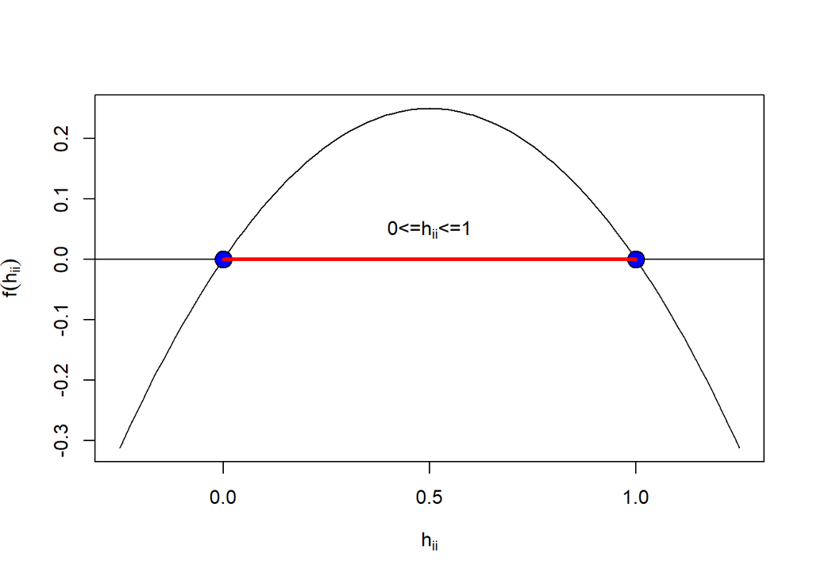

```r
f = function(x) x*(1-x)
curve(f,xlim=c(-0.25,1.25),
      xlab=expression(h[ii]),
      ylab=expression(f(h[ii])))
abline(h=0)
points(c(0,1),c(0,0), bg="blue", cex=2,pch=21)
segments(0,0,1,0,col = "Red", lwd=3)
text(0.5,0.05, expression(paste(0, "<=", h[ii], "<=", 1)))
```

Therefore:

$$0\le h_{ii}\le 1$$

# Studentized residuals

We can make a `studentized residual` vector for the residuals

$$r_i = \frac{\hat{\epsilon}_{i}}{s\sqrt{(1-h_{ii})}}$$

Where $h_{ii}$ is :

$$h_{ii}= x_i^{'}(X^{'}X)^{-1}x_i, \; i=1\ldots n$$

$$V(\hat{\epsilon}_i)=\sigma^2(1-h_{ii})$$

Notice that the variance up to a proportionality constant is simply

$$1-h_{ii}$$

We can calculate these studentized residuals to see if they look extreme.

# Cooks distance

We can see if data are unduely influential on calculation of beta estimates by comparing the squared distance between beta estimates calculated with a row of data removed and those calculated with all the data included. The measure is called `Cook's` distance defined as:

$$D_i = \frac{(\hat{\beta}_{(i)}-\hat{\beta})^{'}X^{'}X(\hat{\beta}_{(i)}-\hat{\beta})}{(k+1)s^2}$$